# Homework 3 Solutions

Master Student

May 2026

## Problem 1

The prior and likelihood are deliberately in conflict: the single observation is `y = 0`, while the prior location for `mu` is 10. The important issue is tail thickness. Normal distributions have thin tails and therefore force a compromise; Student-t distributions with 2 degrees of freedom have heavy tails and can treat one side of the conflict as an extreme but still plausible value.

I estimate the four one-observation posteriors with a dense grid. This is faster and more reliable than MCMC here, especially for the TT model, because the posterior can be bimodal.

```r
y <- 0
mu_grid <- seq(-5, 15, length.out = 4001)

post_grid <- function(likelihood = c("normal", "student"),
                      prior = c("normal", "student")) {
  likelihood <- match.arg(likelihood)
  prior <- match.arg(prior)
  log_lik <- if (likelihood == "normal") {
    dnorm(y, mu_grid, 1, log = TRUE)
  } else {
    dt((y - mu_grid) / 1, df = 2, log = TRUE) - log(1)
  }
  log_prior <- if (prior == "normal") {
    dnorm(mu_grid, 10, 1, log = TRUE)
  } else {
    dt((mu_grid - 10) / 1, df = 2, log = TRUE) - log(1)
  }
  log_post <- log_lik + log_prior
  p <- exp(log_post - max(log_post))
  p <- p / sum(p)
  p
}

p_NN <- post_grid("normal", "normal")
p_TN <- post_grid("student", "normal")
p_NT <- post_grid("normal", "student")
p_TT <- post_grid("student", "student")

p1_summary <- function(p, model) {
  cdf <- cumsum(p)
  data.frame(
    model = model,
    mean = sum(mu_grid * p),
    sd = sqrt(sum((mu_grid - sum(mu_grid * p))^2 * p)),
    q05.5 = mu_grid[which(cdf >= 0.055)[1]],
    q94.5 = mu_grid[which(cdf >= 0.945)[1]],
    mode = mu_grid[which.max(p)]
  )
}

rbind(
  p1_summary(p_NN, "NN: normal likelihood, normal prior"),
  p1_summary(p_TN, "TN: Student likelihood, normal prior"),
  p1_summary(p_NT, "NT: normal likelihood, Student prior"),
  p1_summary(p_TT, "TT: Student likelihood, Student prior")
)
```

```
##                                   model      mean        sd  q05.5  q94.5  mode
## 1   NN: normal likelihood, normal prior 5.0000000 0.7071068  3.870  6.130 5.000
## 2  TN: Student likelihood, normal prior 9.6939049 1.0157944  8.070 11.315 9.695
## 3  NT: normal likelihood, Student prior 0.3060951 1.0157944 -1.315  1.930 0.305
## 4 TT: Student likelihood, Student prior 5.0000000 4.5555854 -0.955 10.955 0.205
```

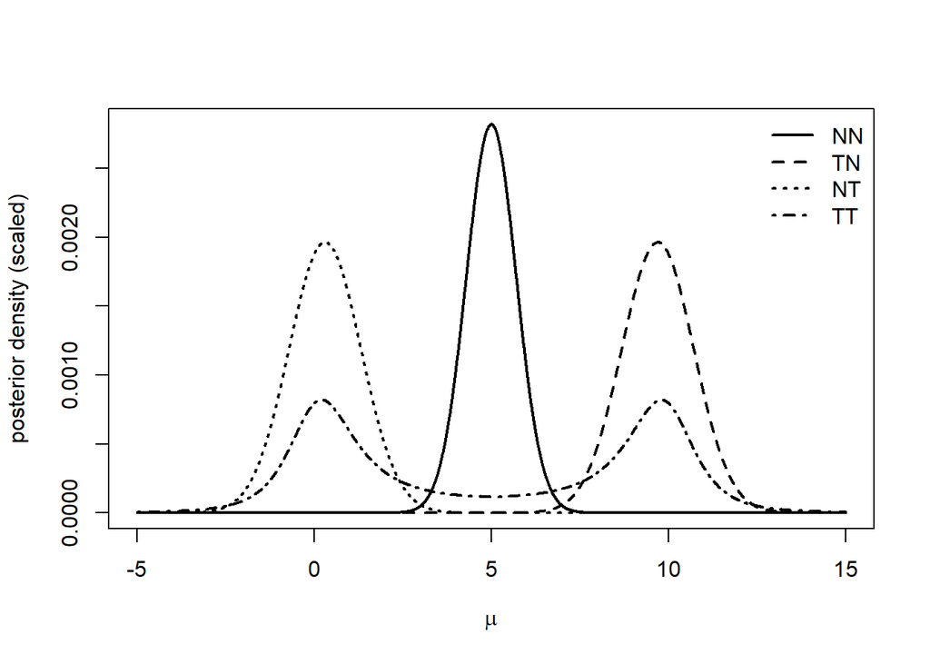

```r
plot(mu_grid, p_NN, type = "l", lwd = 2, xlab = expression(mu), ylab = "posterior density (scaled)")
lines(mu_grid, p_TN, lwd = 2, lty = 2)
lines(mu_grid, p_NT, lwd = 2, lty = 3)
lines(mu_grid, p_TT, lwd = 2, lty = 4)
legend("topright", legend = c("NN", "TN", "NT", "TT"), lty = 1:4, lwd = 2, bty = "n")
```

**Interpretation.**

In **NN**, both likelihood and prior are thin-tailed, so the posterior is a compromise between `y = 0` and prior mean 10. With equal normal standard deviations, it is centered near 5.

In **TN**, the likelihood is Student-t. The model can regard `y = 0` as a tail event under values of `mu` near 10, so the normal prior dominates and the posterior stays near 10.

In **NT**, the prior is Student-t. The prior can regard values of `mu` near 0 as tail events under a distribution centered at 10, while the normal likelihood is thin-tailed and strongly favors `mu` near the data. The posterior therefore moves close to 0.

In **TT**, both sides have heavy tails. The posterior usually has two important regions, one near the observation and one near the prior location. This is why a simple MCMC fit can be harder to diagnose for this model: a chain can spend a long time in only one of the posterior regions.

## Problem 2

The response is ordinal, from 1 to 7. I compare the ordinary ordinal regression model with a varying-intercept model for participants. The varying participant effects use a non-centered parameterization.

```r
data(Trolley)
d <- Trolley

dat <- list(
  R = d$response,
  A = d$action,
  I = d$intention,
  C = d$contact,
  Sid = coerce_index(d$story),
  id = coerce_index(d$id),
  N_id = length(unique(d$id)),
  N_story = length(unique(d$story))
)

str(dat)
```

```
## List of 8
##  $ R      : int [1:9930] 4 3 4 3 3 3 5 4 4 4 ...
##  $ A      : int [1:9930] 0 0 0 0 0 0 1 1 1 1 ...
##  $ I      : int [1:9930] 0 0 0 1 1 1 0 0 0 0 ...
##  $ C      : int [1:9930] 1 1 1 1 1 1 0 0 0 0 ...
##  $ Sid    : int [1:9930] 1 4 8 3 4 11 1 2 3 4 ...
##  $ id     : int [1:9930] 1 1 1 1 1 1 1 1 1 1 ...
##  $ N_id   : int 331
##  $ N_story: int 12
```

```r
m2_base <- ulam(
  alist(
    R ~ dordlogit(phi, cutpoints),
    phi <- bA*A + bC*C + BI*I,
    BI <- bI + bIA*A + bIC*C,
    c(bA, bI, bC, bIA, bIC) ~ dnorm(0, 0.5),
    cutpoints ~ dnorm(0, 1.5)
  ),
  data = dat,
  chains = 4,
  cores = 4,
  log_lik = TRUE
)
```

```
## Running MCMC with 4 parallel chains, with 1 thread(s) per chain...
```

```
## Chain 1 Iteration:   1 / 1000 [  0%]  (Warmup)
```

```
## Chain 2 Iteration:   1 / 1000 [  0%]  (Warmup)
```

```
## Chain 3 Iteration:   1 / 1000 [  0%]  (Warmup)
```

```
## Chain 4 Iteration:   1 / 1000 [  0%]  (Warmup)
```

[output not shown]

```r
m2_id <- ulam(
  alist(
    R ~ dordlogit(phi, cutpoints),
    phi <- bA*A + bC*C + BI*I + a_id[id],
    BI <- bI + bIA*A + bIC*C,

    # non-centered participant intercepts
    transpars> vector[N_id]:a_id <<- z_id * sigma_id,
    vector[N_id]:z_id ~ dnorm(0, 1),
    sigma_id ~ dexp(1),

    c(bA, bI, bC, bIA, bIC) ~ dnorm(0, 0.5),
    cutpoints ~ dnorm(0, 1.5)
  ),
  data = dat,
  chains = 4,
  cores = 4,
  log_lik = TRUE
)
```

```
## Running MCMC with 4 parallel chains, with 1 thread(s) per chain...
```

```
## Chain 1 Iteration:   1 / 1000 [  0%]  (Warmup)
```

```
## Chain 2 Iteration:   1 / 1000 [  0%]  (Warmup)
```

```
## Chain 3 Iteration:   1 / 1000 [  0%]  (Warmup)
```

```
## Chain 4 Iteration:   1 / 1000 [  0%]  (Warmup)
```

[output not shown]

```r
compare(m2_base, m2_id, func = WAIC)
```

```
##             WAIC        SE    dWAIC      dSE     pWAIC weight
## m2_id   31053.64 179.42262    0.000       NA 354.19514      1
## m2_base 36929.06  80.64964 5875.415 173.6249  10.85671      0
```

```r
p2_effects <- rbind(
  trt_summary(m2_base, "no varying intercepts"),
  trt_summary(m2_id, "participant varying intercepts")
)
p2_effects[order(p2_effects$model, p2_effects$rank_abs_mean), ]
```

```
##                             model parameter       mean         sd         lo
## 5           no varying intercepts       bIC -1.2317535 0.09851550 -1.3893760
## 1           no varying intercepts        bA -0.4749048 0.05339362 -0.5635863
## 4           no varying intercepts       bIA -0.4282492 0.07635401 -0.5559018
## 3           no varying intercepts        bC -0.3456201 0.06878334 -0.4543073
## 2           no varying intercepts        bI -0.2945458 0.05592067 -0.3831133
## 10 participant varying intercepts       bIC -1.6691536 0.09869972 -1.8256630
## 6  participant varying intercepts        bA -0.6470661 0.05533230 -0.7354330
## 9  participant varying intercepts       bIA -0.5596560 0.08130202 -0.6892028
## 8  participant varying intercepts        bC -0.4504842 0.07090773 -0.5628455
## 7  participant varying intercepts        bI -0.3831357 0.05888900 -0.4744566
##            hi  abs_mean rank_abs_mean
## 5  -1.0723628 1.2317535             1
## 1  -0.3880766 0.4749048             2
## 4  -0.3064064 0.4282492             3
## 3  -0.2359501 0.3456201             4
## 2  -0.2052271 0.2945458             5
## 10 -1.5071146 1.6691536             1
## 6  -0.5589091 0.6470661             2
## 9  -0.4292354 0.5596560             3
## 8  -0.3347754 0.4504842             4
## 7  -0.2903398 0.3831357             5
```

```r
post_summary(m2_id, "sigma_id")
```

```
##   parameter     mean         sd       lo       hi
## 1  sigma_id 1.915143 0.08017971 1.795056 2.046288
```

**Interpretation.**

The model with participant varying intercepts should have much better expected out-of-sample performance by WAIC. The parameter `sigma_id` measures how much baseline response tendency varies across people. If it is clearly above zero, then some participants are consistently more permissive or more restrictive than others, regardless of the treatment type.

The fixed treatment coefficients should be compared with the table above. Including participant intercepts usually reduces unexplained heterogeneity and often makes the treatment-effect estimates more stable. The important substantive point is that individual differences are not a nuisance detail in these data; they are a major source of response variation.

## Problem 3

Now I add a second varying intercept for story. This is a cross-classified model, because responses are simultaneously clustered by participant and by story. The participant and story effects are both non-centered.

```r
m3_id_story <- ulam(
  alist(
    R ~ dordlogit(phi, cutpoints),
    phi <- bA*A + bC*C + BI*I + a_id[id] + a_story[Sid],
    BI <- bI + bIA*A + bIC*C,

    # non-centered participant intercepts
    transpars> vector[N_id]:a_id <<- z_id * sigma_id,
    vector[N_id]:z_id ~ dnorm(0, 1),
    sigma_id ~ dexp(1),

    # non-centered story intercepts
    transpars> vector[N_story]:a_story <<- z_story * sigma_story,
    vector[N_story]:z_story ~ dnorm(0, 1),
    sigma_story ~ dexp(1),

    c(bA, bI, bC, bIA, bIC) ~ dnorm(0, 0.5),
    cutpoints ~ dnorm(0, 1.5)
  ),
  data = dat,
  chains = 4,
  cores = 4,
  log_lik = TRUE
)
```

```
## Running MCMC with 4 parallel chains, with 1 thread(s) per chain...
```

```
## Chain 1 Iteration:   1 / 1000 [  0%]  (Warmup)
```

```
## Chain 2 Iteration:   1 / 1000 [  0%]  (Warmup)
```

```
## Chain 3 Iteration:   1 / 1000 [  0%]  (Warmup)
```

```
## Chain 4 Iteration:   1 / 1000 [  0%]  (Warmup)
```

[output not shown]

```r
compare(m2_base, m2_id, m3_id_story, func = WAIC)
```

```
##                 WAIC        SE     dWAIC       dSE     pWAIC        weight
## m3_id_story 30567.57 180.36938    0.0000        NA 365.78882  1.000000e+00
## m2_id       31053.64 179.42262  486.0704  42.60495 354.19514 2.825921e-106
## m2_base     36929.06  80.64964 6361.4858 175.33092  10.85671  0.000000e+00
```

```r
p3_effects <- rbind(
  trt_summary(m2_base, "no varying intercepts"),
  trt_summary(m2_id, "participant varying intercepts"),
  trt_summary(m3_id_story, "participant + story varying intercepts")
)
p3_effects[order(p3_effects$model, p3_effects$rank_abs_mean), ]
```

```
##                                     model parameter       mean         sd
## 5                   no varying intercepts       bIC -1.2317535 0.09851550
## 1                   no varying intercepts        bA -0.4749048 0.05339362
## 4                   no varying intercepts       bIA -0.4282492 0.07635401
## 3                   no varying intercepts        bC -0.3456201 0.06878334
## 2                   no varying intercepts        bI -0.2945458 0.05592067
## 15 participant + story varying intercepts       bIC -1.2863672 0.11363990
## 13 participant + story varying intercepts        bC -1.0782271 0.09784426
## 11 participant + story varying intercepts        bA -0.8906277 0.06855060
## 14 participant + story varying intercepts       bIA -0.5274000 0.08593368
## 12 participant + story varying intercepts        bI -0.4595699 0.07047381
## 10         participant varying intercepts       bIC -1.6691536 0.09869972
## 6          participant varying intercepts        bA -0.6470661 0.05533230
## 9          participant varying intercepts       bIA -0.5596560 0.08130202
## 8          participant varying intercepts        bC -0.4504842 0.07090773
```

[output cut: 17 more lines]

```r
post_summary(m3_id_story, c("sigma_id", "sigma_story"))
```

```
##     parameter      mean         sd        lo        hi
## 1    sigma_id 1.9644228 0.08734526 1.8328958 2.1042275
## 2 sigma_story 0.5352438 0.12684265 0.3664048 0.7583091
```

**Interpretation.**

If `sigma_story` is clearly above zero and WAIC improves after adding story intercepts, then different narrative vignettes shift the baseline level of moral approval. That is plausible: even with the same action, intention, and contact labels, some stories can sound more or less acceptable.

The rank order of the treatment coefficients should be checked in the `p3_effects` table. The usual pattern is that the large treatment-type effects remain qualitatively similar, but their magnitudes can shift when story is added. If the rank order changes, the reason is that the treatment indicators are not perfectly separated from story content. Some treatment combinations appear in particular kinds of narratives, so ignoring story can partially mix the treatment effect with baseline differences among stories.

## Problem 4

The Primates301 data include body mass measurements for 238 species after dropping species with missing body mass. Among these 238 species, 56 brain measurements are missing. First I inspect whether missing brain values are associated with body mass.

```r
data(Primates301)
d4 <- Primates301[!is.na(Primates301$body), ]
d4$brain_missing <- is.na(d4$brain)

nrow(d4)
```

```
## [1] 238
```

```r
sum(d4$brain_missing)
```

```
## [1] 56
```

```r
table(d4$brain_missing)
```

```
##
## FALSE  TRUE
##   182    56
```

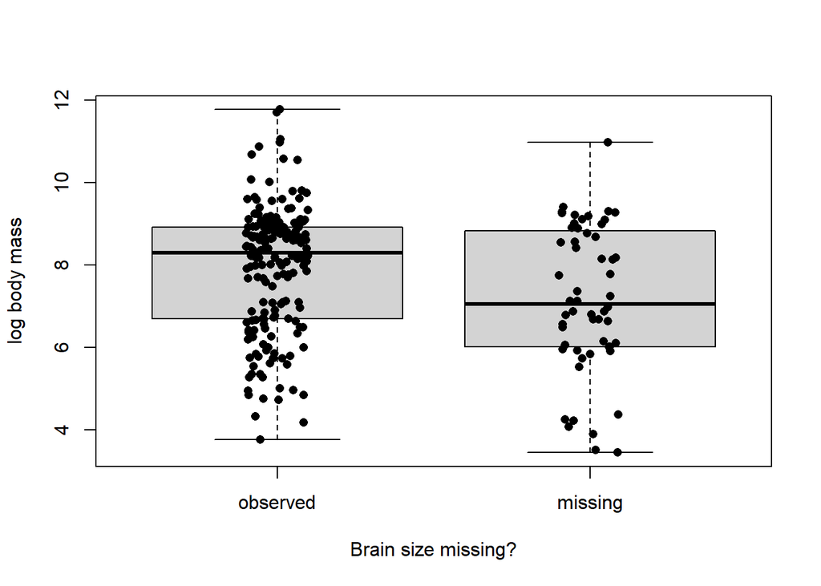

```r
boxplot(
  log(body) ~ brain_missing,
  data = d4,
  xlab = "Brain size missing?",
  ylab = "log body mass",
  names = c("observed", "missing")
)

stripchart(
  log(body) ~ brain_missing,
  data = d4,
  vertical = TRUE,
  method = "jitter",
  add = TRUE,
  pch = 16
)
```

A simple DAG for the missingness pattern is:

```
body mass  ---->  brain size
    |
    v
brain-size missingness  ---->  observed brain variable
```

The visible pattern is not MCAR, because the probability that brain size is missing appears to vary with body mass. Under the DAG above, the missingness is **MAR conditional on body mass**: missingness depends on an observed variable, body mass. It would be MNAR only if missingness also depended directly on the unobserved true brain size after conditioning on body mass; that is possible in principle, but it is not identified from these data alone.

Now I compare a complete-case model with a model that imputes the missing brain sizes. To keep the two analyses comparable, I scale body mass using the maximum body mass in the 238-species body-observed subset, and I scale brain size using the maximum observed brain size.

```r
B_all <- d4$brain / max(d4$brain, na.rm = TRUE)
M_all <- d4$body / max(d4$body, na.rm = TRUE)
miss_B <- is.na(B_all)

# Complete-case model
m4_cc <- ulam(
  alist(
    B ~ dlnorm(mu, sigma),
    mu <- a + b*log(M),
    a ~ dnorm(0, 1),
    b ~ dnorm(0, 1),
    sigma ~ dexp(1)
  ),
  data = list(B = B_all[!miss_B], M = M_all[!miss_B]),
  chains = 4,
  cores = 4
)
```

[output not shown]

[output not shown]

[output not shown]

[output not shown]

[output not shown]

```r
# Missing-outcome imputation model
m4_imp <- ulam(
  alist(
    B ~ dlnorm(mu, sigma),
    mu <- a + b*log(M),
    a ~ dnorm(0, 1),
    b ~ dnorm(0, 1),
    sigma ~ dexp(1)
  ),
  data = list(B = B_all, M = M_all),
  chains = 4,
  cores = 4,
  start = list(B_impute = rep(0.5, sum(miss_B)))
)
```

```
## Running MCMC with 4 parallel chains, with 1 thread(s) per chain...
##
## Chain 1 Iteration:   1 / 1000 [  0%]  (Warmup)
```

```
## Chain 2 Iteration:   1 / 1000 [  0%]  (Warmup)
```

```
## Chain 3 Iteration:   1 / 1000 [  0%]  (Warmup)
```

```
## Chain 4 Iteration:   1 / 1000 [  0%]  (Warmup)
```

[output not shown]

[output not shown]

[output not shown]

[output not shown]

[output not shown]

[output not shown]

[output not shown]

[output not shown]

[output not shown]

[output not shown]

[output not shown]

[output not shown]

[output not shown]

[output not shown]

[output not shown]

[output not shown]

[output not shown]

[output not shown]

[output not shown]

[output not shown]

[output not shown]

```r
rbind(
  cbind(model = "complete cases", post_summary(m4_cc, c("a", "b", "sigma"))),
  cbind(model = "brain imputed", post_summary(m4_imp, c("a", "b", "sigma")))
)
```

```
##            model parameter      mean         sd        lo        hi
## 1 complete cases         a 0.4290511 0.05500357 0.3395878 0.5135602
## 2 complete cases         b 0.7834746 0.01340242 0.7623219 0.8046687
## 3 complete cases     sigma 0.2929211 0.01582764 0.2688960 0.3198594
## 4  brain imputed         a 0.4261893 0.05678470 0.3356885 0.5206609
## 5  brain imputed         b 0.7831917 0.01378972 0.7613342 0.8059013
## 6  brain imputed     sigma 0.2926228 0.01549478 0.2680998 0.3184680
```

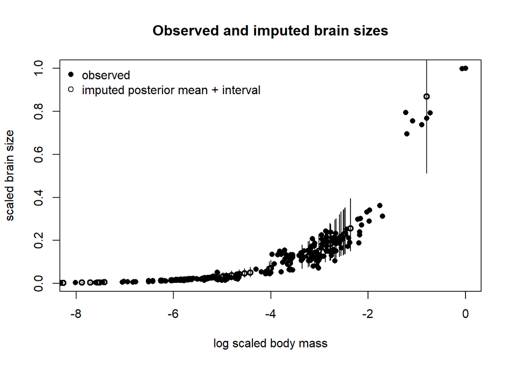

```r
post_imp <- extract.samples(m4_imp)
B_imp_mean <- apply(post_imp$B_impute, 2, mean)
B_imp_PI <- apply(post_imp$B_impute, 2, PI)

plot(
  log(M_all[!miss_B]), B_all[!miss_B],
  pch = 16,
  xlab = "log scaled body mass",
  ylab = "scaled brain size",
  main = "Observed and imputed brain sizes"
)
points(log(M_all[miss_B]), B_imp_mean, pch = 1, lwd = 2)
for (i in seq_along(B_imp_mean)) {
  lines(rep(log(M_all[miss_B][i]), 2), B_imp_PI[, i])
}
legend(
  "topleft",
  legend = c("observed", "imputed posterior mean + interval"),
  pch = c(16, 1),
  bty = "n"
)
```

**Interpretation.**

The complete-case model drops all species with missing brain values. Since missing brain values are concentrated in a particular range of body masses, this deletion changes the density of the data used to estimate the body–brain relationship. The imputation model keeps those species in the likelihood by treating their brain sizes as unknown parameters constrained by the lognormal body–brain relationship.

The slope `b` and residual scale `sigma` may change modestly, but the key difference is conceptual: the imputation model propagates uncertainty about the missing brain sizes instead of pretending that those species do not exist. If the imputed points fall mostly in the low-body-mass region, then complete-case analysis has underrepresented exactly that part of the regression.